# ProjectMA-Bugs Bunny

# Abstract

Below dataset covers information about gender,student performance (math, reading, writing); etnicity; level of education; lunch(free/reduced); test-preparation course. Dataset is retrieved from kaggle[1].Classification andlogistic regression methods are investigated in this study.

Decision tree is going to be used as classification method in the first model. In the second model, gender of students are tried to be predicted with logistic regression.Study will start with an explanatory data analysis. Pre-processing part will follow it. Finally, results are going to be discussed for both models, separately.

## Explanatory Data Analysis

Features

```
##   gender race.ethnicity parental.level.of.education        lunch
## 1 female        group B           bachelor's degree     standard
## 2 female        group C                some college     standard
## 3 female        group B             master's degree     standard
## 4   male        group A          associate's degree free/reduced
##   test.preparation.course math.score reading.score writing.score
## 1                    none         72            72            74
## 2               completed         69            90            88
## 3                    none         90            95            93
## 4                    none         47            57            44
```

Dimensions of Data

```
## [1] 1000    8
```

Data Types of Features:

```
## 'data.frame':    1000 obs. of  8 variables:
##  $ gender                     : Factor w/ 2 levels "female","male": 1 1 1 2 2 1 1 2 2 1 ...
##  $ race.ethnicity             : Factor w/ 5 levels "group A","group B",..: 2 3 2 1 3 2 2 2 4 2 ...
##  $ parental.level.of.education: Factor w/ 6 levels "associate's degree",..: 2 5 4 1 5 1 5 5 3 3 ...
##  $ lunch                      : Factor w/ 2 levels "free/reduced",..: 2 2 2 1 2 2 2 1 1 1 ...
##  $ test.preparation.course    : Factor w/ 2 levels "completed","none": 2 1 2 2 2 2 1 2 1 2 ...
##  $ math.score                 : int  72 69 90 47 76 71 88 40 64 38 ...
##  $ reading.score              : int  72 90 95 57 78 83 95 43 64 60 ...
##  $ writing.score              : int  74 88 93 44 75 78 92 39 67 50 ...
```

Summary of Scores:

In below summary, it is seen that mean & median scores of reading, writing and math are quite close within each group.Therefore, we can assume normal distribution. In the sense of gender distribution, we have a balanced dataset.

```
##     gender    race.ethnicity     parental.level.of.education
##  female:518   group A: 89    associate's degree:222
##  male  :482   group B:190    bachelor's degree :118
##               group C:319    high school       :196
##               group D:262    master's degree   : 59
##               group E:140    some college      :226
##                              some high school  :179
##           lunch     test.preparation.course   math.score
##  free/reduced:355   completed:358           Min.   :  0.00
##  standard    :645   none     :642           1st Qu.: 57.00
##                                             Median : 66.00
##                                             Mean   : 66.09
##                                             3rd Qu.: 77.00
##                                             Max.   :100.00
##  reading.score    writing.score
##  Min.   : 17.00   Min.   : 10.00
##  1st Qu.: 59.00   1st Qu.: 57.75
##  Median : 70.00   Median : 69.00
##  Mean   : 69.17   Mean   : 68.05
##  3rd Qu.: 79.00   3rd Qu.: 79.00
##  Max.   :100.00   Max.   :100.00
```

Outlier Detection:

However, upper and lower boundaries for math, reading and writing courses are calculated with respect to IQR scores. Count of outliers, which are below than lower threshold, are also listed in below. Total count is not significant, so we don’t need to elimate them.

[output not shown]

```
##                         Math Reading Writing
## Count of lower Outliers    8       6       9
```

There is no NAN values

```r
sum(is.na(original))
```

```
## [1] 0
```

Distribution of writing, math and reading scores

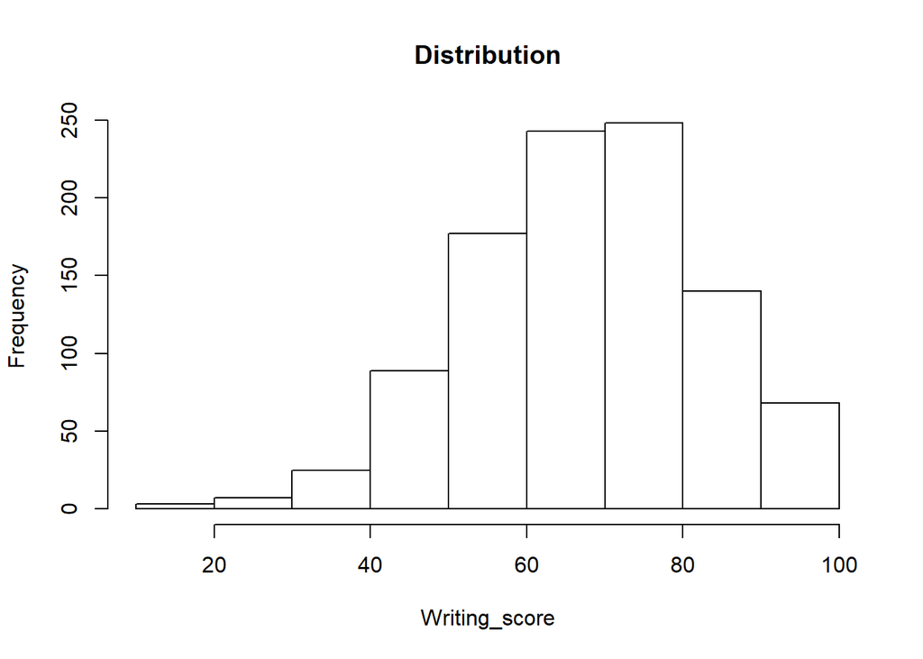

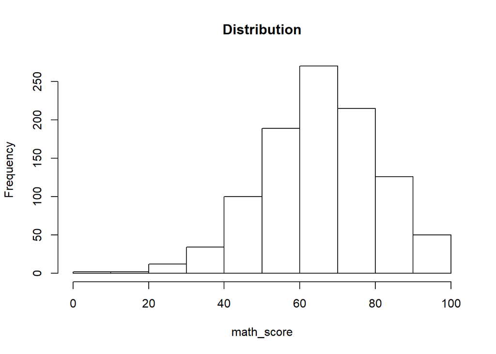

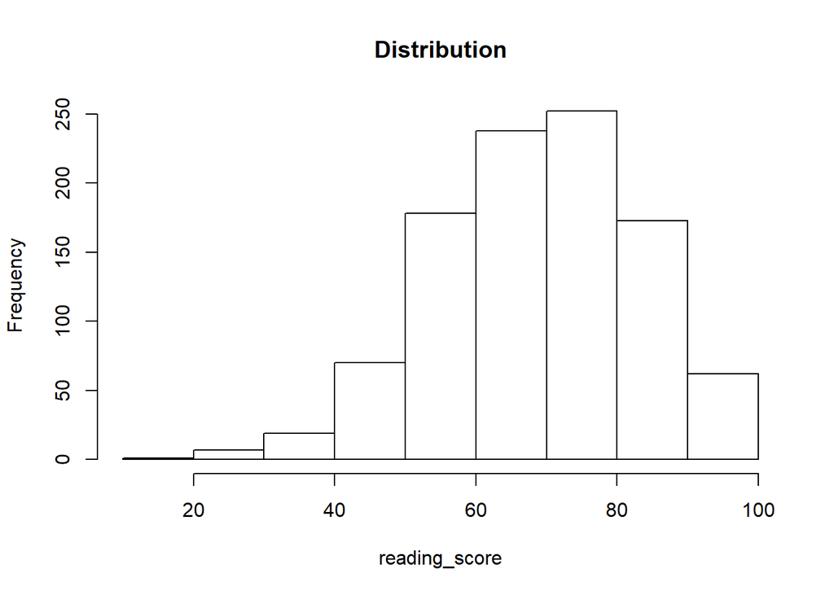

# Model- Result & Discussion

In the first model, gender classification is done. Training and testing data are taken as 80% and 20%, respectively.

Equation

In below equation, max dept is set to 4, after trial& errors.Overfitting issue is avoided.

```r
m <- rpart(gender~., data= original_train, method="class", maxdepth=4)
```

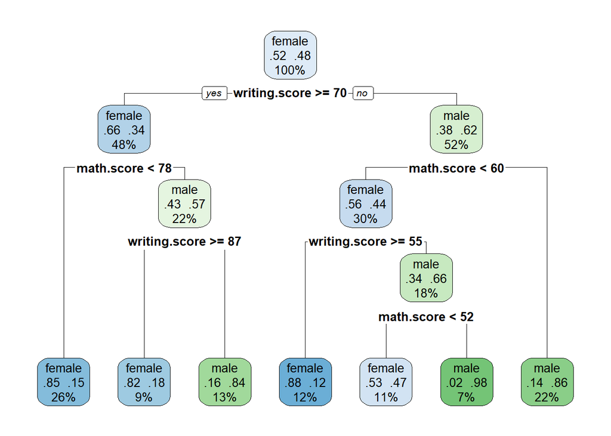

- All the features are feed into data, and classification is done based exam scores.
- In the first model, it is seen that, writing score with threshold 70, is the most deterministic  
  factor. All population is distributed by 48%-52% based on this.
- Math score is the second important discriminative factor.
- Accuracy difference between test and training data set is around 3%, so there is no issue on overfitting.
- Model can be evaluated as good enough, with 79% accuracy on test set.

```r
original_test$pred <- predict(m, original_test, type = "class")
mean(original_test$pred == original_test$gender)
```

```
## [1] 0.79
```

```r
original_train$pred <- predict(m, original_train, type = "class")
mean(original_train$pred == original_train$gender)
```

```
## [1] 0.82625
```

### Model 2- Logistic Regression

Equation

```r
model <- glm(gender ~ math.score+writing.score+reading.score,
                      data = original_train, family = "binomial"(link ='logit'))
```

Accuracy for train set

```r
mean(original_train$prediction==original_train$gender)
```

```
## [1] 0.87875
```

Accuracy for test set

```r
mean(original_test$prediction==original_test$gender
     )
```

```
## [1] 0.875
```

# Model2- Result & Discussion

Better accuracy (~ 87%) is obtained in logistic regression.Test and train accuracies are quite similar, which indicates a trustable model.

# Main Take Aways

Logistic regression gave higher accuracy score.The reason would be the fact that, dataset has good distribution, which is quite close to gaussion. If the dataset was larger than 1000 samples, accuracy of decision tree would be higher.The reason is decision tree is very expensive in terms of sample size.Therefore it requires higher amount of data size for higher accuracy.

# References

```r
#[1] Students Performance in Exams. (n.d.). Retrieved from https://www.kaggle.com/spscientist/students-performance-in-exams
```